# Отчет по лабораторной работе № 4

Базовая настройка HTTP-сервера Apache

Бызова Мария Олеговна

2025-09-23

## Цель работы

Целью данной работы является приобретение практических навыков по установке и базовому конфигурированию HTTP-сервера Apache.

# Выполнение лабораторной работы

## Установка HTTP-сервера

Загрузим нашу операционную систему и перейдём в рабочий каталог с проектом. Далее запустим виртуальную машину server (рис. 1)

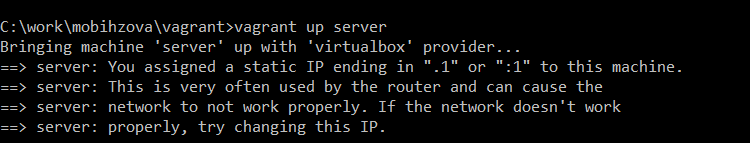

Рисунок 1: Открытие рабочего каталога с проектом и запуск виртуальной машины server.

## Установка HTTP-сервера

На виртуальной машине server войдём под нашим пользователем и откроем терминал. Далее перейдём в режим суперпользователя и установим из репозитория стандартный веб-сервер (HTTP-сервер и утилиты httpd, криптоутилиты и пр.) (рис. 2)

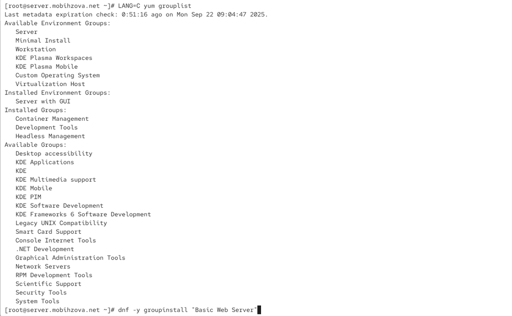

Рисунок 2: Переход в режим суперпользователя и установка из репозитория стандартного веб-сервера.

## Базовое конфигурирование HTTP-сервера

Посмотрим какие конфигурационные файлы есть в каталогах /etc/httpd/conf и /etc/httpd/conf.d ((рис. 3) - (рис. 11)).

## Базовое конфигурирование HTTP-сервера

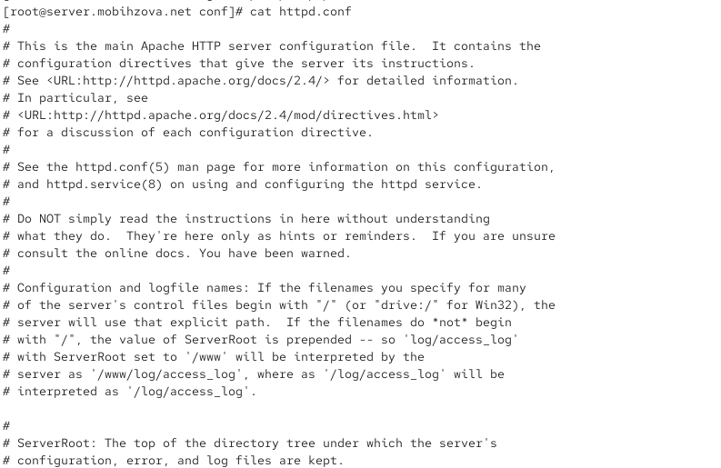

Рисунок 3: Файл httpd.conf

## Базовое конфигурирование HTTP-сервера

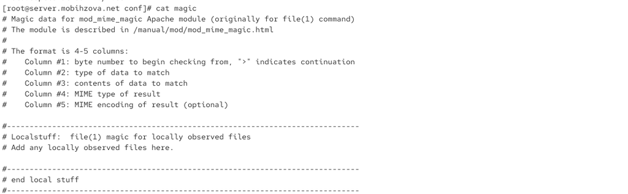

Рисунок 4: Файл magic

## Базовое конфигурирование HTTP-сервера

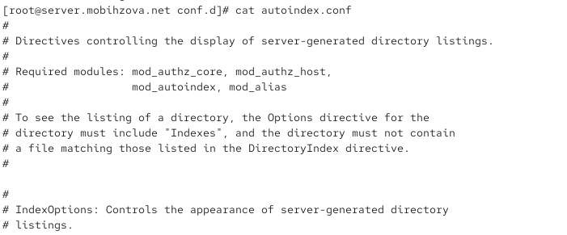

Рисунок 5: Файл autoindex.conf

## Базовое конфигурирование HTTP-сервера

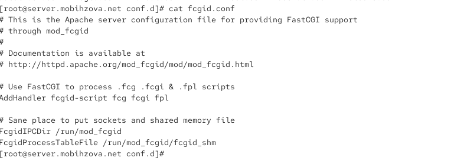

Рисунок 6: Файл fcgid.conf

## Базовое конфигурирование HTTP-сервера

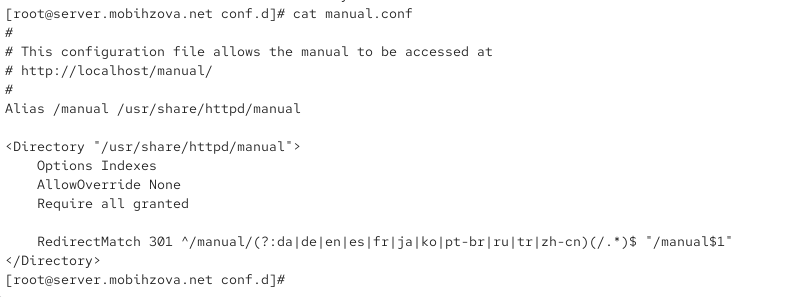

Рисунок 7: Файл manual.conf

## Базовое конфигурирование HTTP-сервера

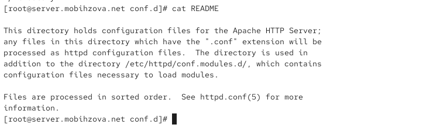

Рисунок 8: Файл README

## Базовое конфигурирование HTTP-сервера

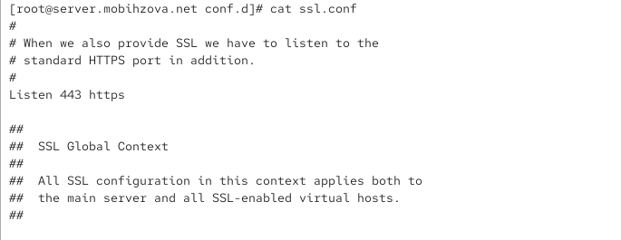

Рисунок 9: Файл ssl.conf

## Базовое конфигурирование HTTP-сервера

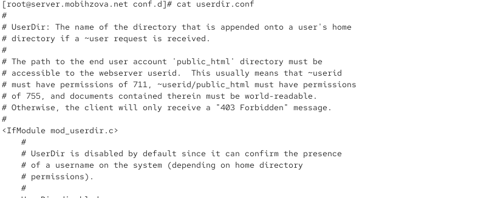

Рисунок 10: Файл userdir.conf

## Базовое конфигурирование HTTP-сервера

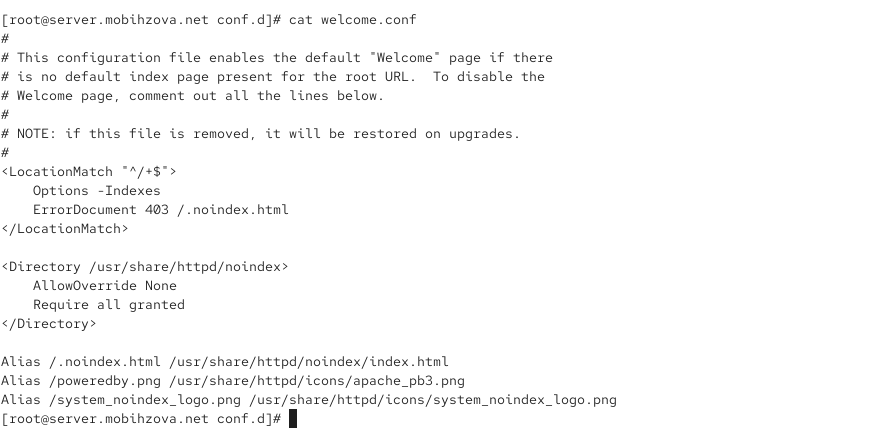

Рисунок 11: Файл welcome.conf

## Базовое конфигурирование HTTP-сервера

Внесём изменения в настройки межсетевого экрана узла server, разрешив работу с http (рис. 12).

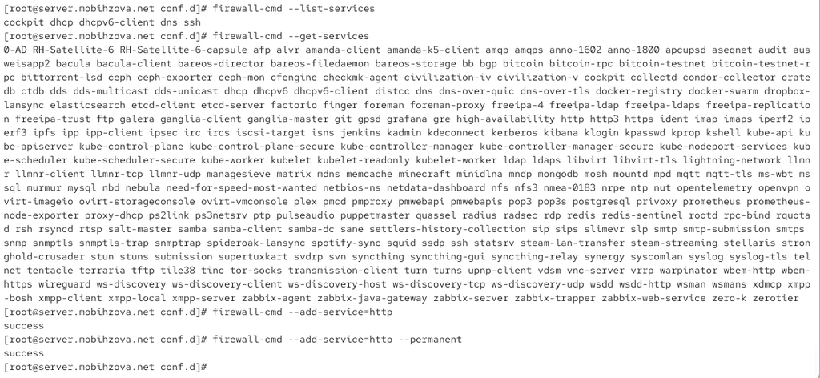

Рисунок 12: Внесение изменений в настройки межсетевого экрана узла server, разрешив работу с http.

## Базовое конфигурирование HTTP-сервера

В дополнительном терминале запустим в режиме реального времени расширенный лог системных сообщений, чтобы проверить корректность работы системы (рис. 13).

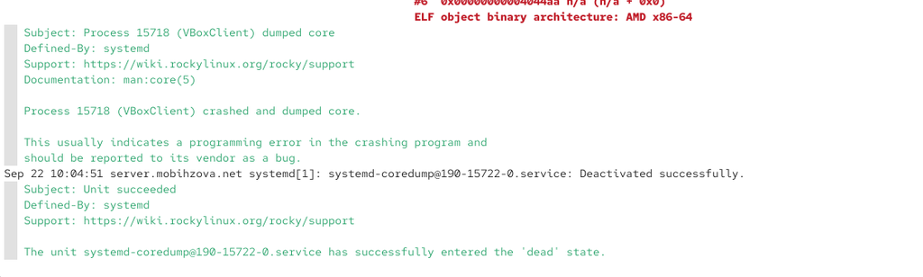

Рисунок 13: Запуск в дополнительном терминале в режиме реального времени расширенного лога системных сообщений для проверки корректности работы системы

## Базовое конфигурирование HTTP-сервера

В первом терминале активируем и запустим HTTP-сервер (рис. 14).

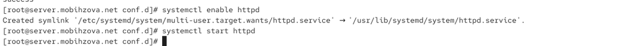

Рисунок 14: Активация и запуск HTTP-сервера.

## Базовое конфигурирование HTTP-сервера

Просмотрим расширенный лог системных сообщений, убедимся, что веб-сервер успешно запустился.

## Анализ работы HTTP-сервера

Запустим виртуальную машину client. На виртуальной машине server просмотрим лог ошибок работы веб-сервера. Далее запустим мониторинг доступа к веб-серверу. (рис. 15)

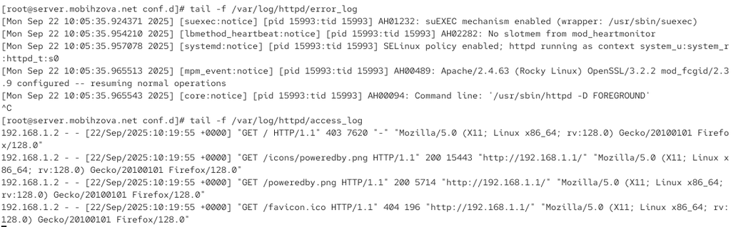

Рисунок 15: Запуск мониторинга ошибок и доступа к веб-серверу на виртуальной машине server.

## Анализ работы HTTP-сервера

На виртуальной машине client запустим браузер и в адресной строке введём 192.168.1.1 (рис. 16)

[figure not shown]

Рисунок 16: Запуск браузера на виртуальной машине client и ввод в адресной строке 192.168.1.1.

## Настройка виртуального хостинга для HTTP-сервера

Остановим работу DNS-сервера для внесения изменений в файлы описания DNS-зон (рис. 17)

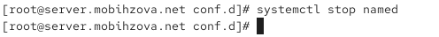

Рисунок 17: Остановка работы DNS-сервера для внесения изменений в файлы описания DNS-зон.

## Настройка виртуального хостинга для HTTP-сервера

Теперь добавим запись для HTTP-сервера в конце файла прямой DNS-зоны (рис. 18)

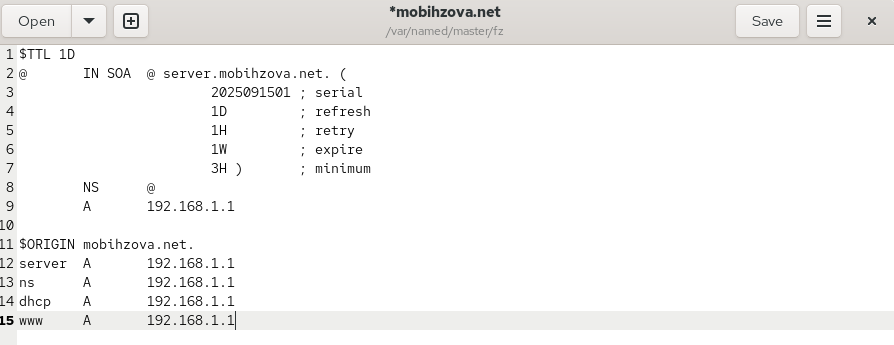

Рисунок 18: Добавление записи для HTTP-сервера в конце файла прямой DNS-зоны

## Настройка виртуального хостинга для HTTP-сервера

Также в конце файла обратной зоны /var/named/master/rz/192.168.1 (рис. 19)

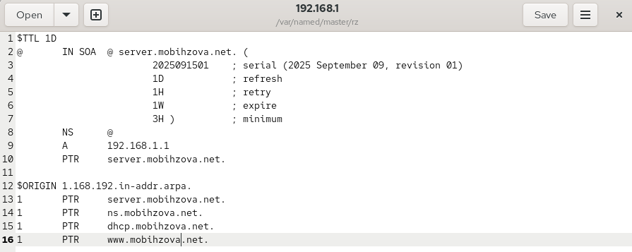

Рисунок 19: Добавление записи для HTTP-сервера в конце файла обратной DNS-зоны /var/named/master/rz/192.168.1.

## Настройка виртуального хостинга для HTTP-сервера

Перезапустим DNS-сервер. В каталоге /etc/httpd/conf.d создадим файлы server.mobihzova.net.conf и www.mobihzova.net.conf (рис. 20)

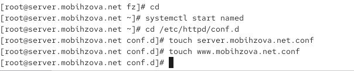

Рисунок 20: Перезапуск DNS-сервера и создание в каталоге /etc/httpd/conf.d файлов

## Настройка виртуального хостинга для HTTP-сервера

Откроем на редактирование файл server.mobihzova.net.conf и внесём туда следующее содержание (рис. 21)

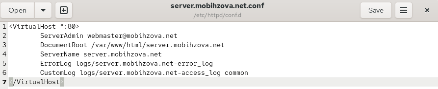

Рисунок 21: Редактирование файла

## Настройка виртуального хостинга для HTTP-сервера

Откроем на редактирование файл www.mobihzova.net.conf и внесём туда следующее содержание (рис. 22)

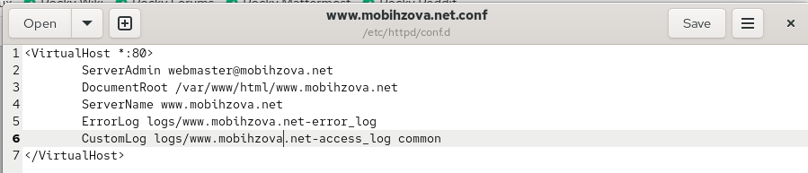

Рисунок 22: Редактирование файла

## Настройка виртуального хостинга для HTTP-сервера

Перейдём в каталог /var/www/html, в котором находятся файлы с содержимым (контентом) веб-серверов, и создадим тестовые страницы для виртуальных веб-серверов. Для виртуального веб-сервера server.mobihzova.net (рис. 23)

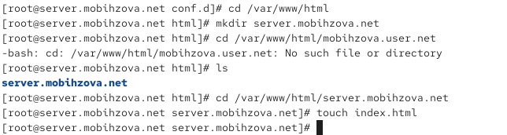

Рисунок 23: Открытие каталога /var/www/html и создание тестовой страницы для виртуального веб-сервера

## Настройка виртуального хостинга для HTTP-сервера

Откроем на редактирование файл index.html и внесём следующее содержание (рис. 24)

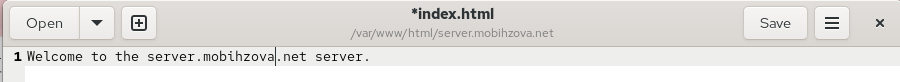

Рисунок 24: Редактирование файла

## Настройка виртуального хостинга для HTTP-сервера

Для виртуального веб-сервера www.mobihzova.net (рис. 25)

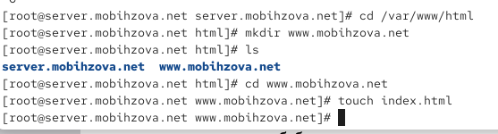

Рисунок 25: Открытие каталога /var/www/html и создание тестовой страницы для виртуального веб-сервера

## Настройка виртуального хостинга для HTTP-сервера

Откроем на редактирование файл index.html и внесём следующее содержание (рис. 26)

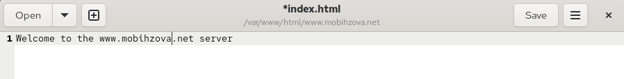

Рисунок 26: Редактирование файла

## Настройка виртуального хостинга для HTTP-сервера

Скорректируем права доступа в каталог с веб-контентом. Далее восстановим контекст безопасности в SELinux(рис. 27)

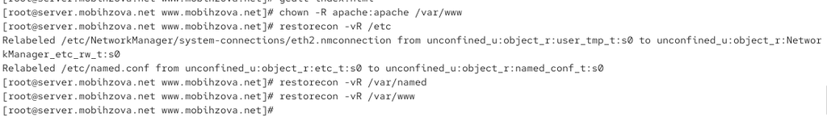

Рисунок 27: Исправление прав доступа в каталог с веб-контентом, восстановление контекста безопасности в SELinux

## Настройка виртуального хостинга для HTTP-сервера

Теперь перезапустим HTTP-сервер (рис. 28)

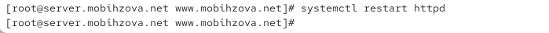

Рисунок 28: Перезапуск сервера